# Analiza

Jakub Milasz

2025-01-22

```r
library(sf)
library(dbscan)
```

```r
library(ggplot2)
library(dplyr)
# Ustawienie katalogu roboczego
setwd("~/ArcGIS/Projects/project")

# Wczytanie danych
osiedla <- read_sf(dsn="dane/osiedla/", layer = "osiedla")
przestepstwa <- read_sf(dsn="dane/projected_data/", layer = "projected_data")

# Skopiowanie tabeli przestępstw na potrzeby hdbscan
przestepstwa_hdbscan <- przestepstwa

# Ekstrakcja współrzędnych przestępstw
coords <- st_coordinates(przestepstwa)
```

**DBSCAN**

Zasada działania algorytmu:

1. Wybieramy parametry:
1. eps - promień otoczenia, w którym sprawdzam ilość sąsiadów dla danego punktu
2. minPts - minimalna ilość punktów, aby powstał klaster
2. Szukamy punktów, które w promieniu eps mają co najmniej minPts punktów (razem z nim). Takie punkty nazywamy punktami rdzeniowymi. Punkty należące do okręgu, ale niebędące rdzeniowymi nazywamy punktami bezpośrednio osiągalnymi z rdzenia. Pozostałe to szum.
3. Klaster jest tworzony przez punkt rdzeniowy i wszystkie punkty bezpośrednio z niego osiągalne.

Zalety:

1. DBSCAN nie wymaga określenia a priori liczby klastrów w danych, w przeciwieństwie do metody k-średnich.
2. DBSCAN może znaleźć dowolnie ukształtowane klastry. Może nawet znaleźć klaster całkowicie otoczony przez inny klaster (ale nie połączony z nim). Dzięki parametrowi MinPts zredukowany został tzw. efekt single-link (różne klastry połączone cienką linią punktów).
3. DBSCAN wydziela szum i jest odporny na wartości odstające.
4. DBSCAN wymaga tylko dwóch parametrów i jest w większości przypadków niewrażliwy na kolejność punktów w bazie danych.
5. Parametry minPts i ε mogą być ustawione przez eksperta w danej dziedzinie, jeśli dane są dobrze zrozumiane.

Wady:

1. DBSCAN nie jest całkowicie deterministyczny: punkty graniczne, które są osiągalne z więcej niż jednego klastra, mogą być częścią któregoś z nich, w zależności od kolejności przetwarzania danych. Dla punktów rdzeniowych, jak i punktach szumu, DBSCAN jest deterministyczny.
2. Jakość DBSCAN zależy od miary odległości. Najczęściej stosowaną metryką odległości jest odległość euklidesowa. Szczególnie w przypadku danych wielowymiarowych, metryka ta może stać się prawie bezużyteczna z powodu tak zwanej “klątwy wymiarowości”, co utrudnia znalezienie odpowiedniej wartości dla eps. Efekt ten występuje jednak również w każdym innym algorytmie bazującym na odległości euklidesowej.
3. DBSCAN nie może dobrze klasteryzować zbiorów danych o dużych różnicach gęstości, ponieważ nie można wtedy odpowiednio dobrać kombinacji minPts - eps dla wszystkich klastrów.

```r
# Ustalenie parametrów DBSCAN
eps <- 200
minPts <- 4  # minimalna liczba punktów w sąsiedztwie

# Przeprowadzenie analizy DBSCAN za pomocą funkcji dbscan()
dbscan_result <- dbscan(coords, eps = eps, minPts = minPts)

# Dodanie wyników klastra do ramki danych przestępstw
przestepstwa$cluster <- dbscan_result$cluster
# Usunięcie szumu
przestepstwa <- filter(przestepstwa, przestepstwa$cluster != 0)

# Wyświetlenie wyników
print(table(przestepstwa$cluster))
```

```
##
##   1   2   3   4   5   6   7   8   9  10  11  12  13  14  15  16  17  18  19  20
##   8  47   5 936  13  44  18   4  13   5  37  23  17  65   4   5   5  10   5   5
##  21  22  23  24  25  26  27  28  29  30  31  32  33  34  35  36  37  38  39  40
##   5   6   4   4   4   9  12   5   5  16   4   4   9   4   7  18   7   6  10  19
##  41  42  43  44  45  46  47  48  49  50  51  52  53  54  55  56  57  58  59  60
##   5   8  10   8   4   5   7   4   5  10   4  11   7   5   5   6   6   5   4   4
##  61  62  63  64  65  66  67  68  69  70  71
##   4   8   4   4   4   4   6   3   4   5   4
```

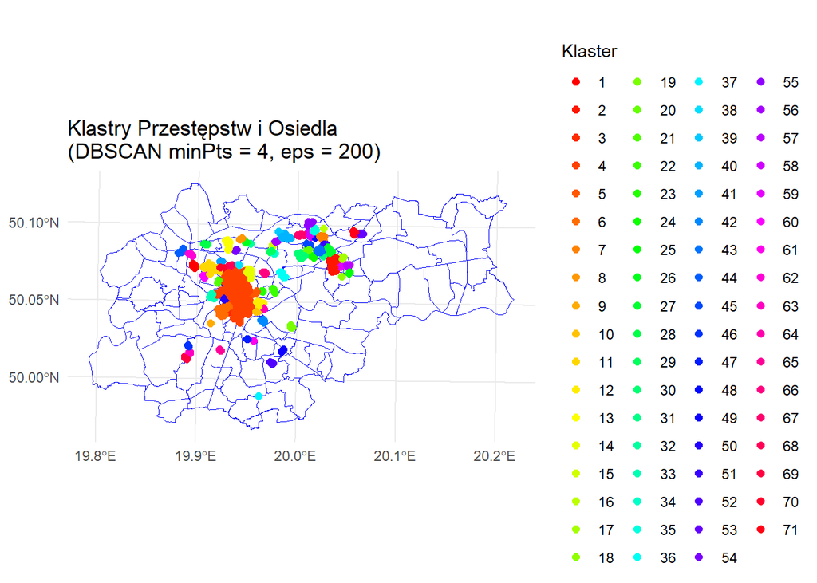

```r
# Wizualizacja
library(ggplot2)
ggplot() +
  geom_sf(data = osiedla, fill = NA, color = 'blue') + # Osiedla
  geom_sf(data = przestepstwa, aes(color = factor(cluster)), size = 2) + # Przestępstwa
  scale_color_manual(values = rainbow(length(unique(przestepstwa$cluster)))) + # Kolory klastrów
  theme_minimal() +
  labs(title = "Klastry Przestępstw i Osiedla\n(DBSCAN minPts = 4, eps = 200)",
       color = "Klaster") +
  theme(legend.position = "right")
```

**HDBSCAN**

Zasada działania:

Algorytm ten jest rozwinięcie DBSCAN. Identyfikuje tzw. rdzenie klastrów jako te punkty, w sąsiedztwie których (tzn. bliżej niż zadana wartość graniczna eps – promień sąsiedztwa) zlokalizowana jest wystarczająca ilość punktów sąsiadujących (większa bądź równa przyjętej wartości granicznej). Do tak zdefiniowanych rdzeni klastrów dołączane są punkty pozostające w bliskiej odległości od któregokolwiek z punktów rdzenia (bliżej niż zadana wartość), które w sumie tworzą klaster. Punkty niezakwalifikowane do żadnego klastra są określane jako szum

Zalety:

1. HDBSCAN generuje hierarchiczną strukturę klastrów, co pozwala lepiej analizować złożone dane i identyfikować różne poziomy zagęszczenia w danych.
2. Algorytm nie wymaga a priori określenia liczby klastrów, co jest dużą zaletą w porównaniu do algorytmów takich jak k-means.
3. HDBSCAN jest skuteczny w identyfikacji szumów i danych odstających, co może poprawić jakość generowanych klastrów.
4. Potrafi radzić sobie z danymi o różnej gęstości, co czyni go bardziej elastycznym w porównaniu do standardowego DBSCAN.
5. W porównaniu do innych algorytmów hierarchicznych, HDBSCAN jest stosunkowo szybki i efektywny pod względem obliczeniowym.

Wady:

1. Chociaż HDBSCAN eliminuje konieczność określania liczby klastrów, nadal wymaga ustawienia minimalnej wielkości próbki („min_samples”), co może być trudne do optymalizacji.
2. Chociaż HDBSCAN jest stosunkowo szybki, wciąż może mieć problemy z wydajnością przy bardzo dużych zbiorach danych w porównaniu do prostszych algorytmów.
3. Ze względu na swoją złożoność matematyczną i koncepcyjną, może być trudniejszy w zrozumieniu i wdrożeniu w porównaniu do bardziej podstawowych algorytmów klasteryzacji.

```r
# Przeprowadzenie analizy HDBSCAN za pomocą funkcji hdbscan()
hdbscan_result <- hdbscan(coords, minPts = 30)

# Dodanie wyników klastra do ramki danych przestępstw
przestepstwa_hdbscan$cluster <- as.factor(hdbscan_result$cluster)

# Usunięcie szumu
przestepstwa_hdbscan <- filter(przestepstwa_hdbscan, przestepstwa_hdbscan$cluster != 0)

# Wyświetlenie wyników
print(table(przestepstwa_hdbscan$cluster))
```

```
##
##    0    1    2    3
##    0  180   42 1302
```

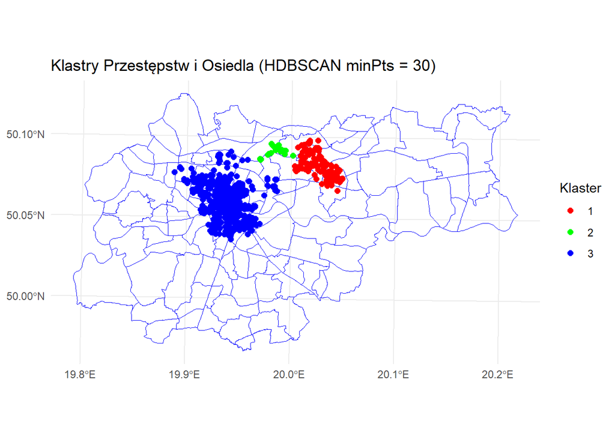

```r
# Wizualizacja
ggplot() +
  geom_sf(data = osiedla, fill = NA, color = 'blue') + # Osiedla
  geom_sf(data = przestepstwa_hdbscan, aes(color = cluster), size = 2) + # Przestępstwa
  scale_color_manual(values = rainbow(length(unique(przestepstwa_hdbscan$cluster)))) +
  theme_minimal() +
  labs(title = "Klastry Przestępstw i Osiedla (HDBSCAN minPts = 30)",
       color = "Klaster") +
  theme(legend.position = "right")
```

**Porównanie wyników i wnioski**

Jak można zauważyć, w tym przypadku metodą DBSCAN otrzymaliśmy dużo klastrów ze względu na wartość parametru minPts = 4. Mała wartość tego parametru charakteryzuje się dużą ilością klastrów, ale zasadniczo jest poprawna, ponieważ przyjmuje się, że minPts >= 2D, gdzie D to liczba wymiarów (w tym wypadku D=2). Natomiast w metodzie HDBSCAN ustawiłem parametr minPts = 30, ponieważ dla minPts = 4 wynik nie był zadowalający. Im wyższa wartość minPts, tym klasteryzacja jest bardziej konserwatywna i większa liczba punktów będzie umieszczana jako szum. Odnosząc się do lokalizacji klastrów można zauważyć, że największe zagęszczenie przestępstw występuje w centrum miasta (dla obu metod powstał tam duży klaster). Może to być spowodowane najwiekszym gromadzeniem się ludności właśnie tam. Drugim miejscem, w którym można zauważyć wzmożoną aktywność przestępczą są osiedla położone na północny wschód od centrum (m. in. Bieńczyce i Krzesławice). Bardzo klarownie przedstawia to klasteryzacja metodą HDBSCAN. Pozostałe osiedla cechują się stosunkowo niskim poziomem przestępczości.